# **Exploring Life Tables**

# Introduction

Using IMHE and Census Data we complied a life table together in R for Palau in 2015. This was a very labour intensive process. We took our $_na_x$ values from Tawian in 1970, which we found to have a similar life expectancy as Palau. We got this data from the Human Mortality Database (HMD). We also decomposed the gender difference in life expectancy, saw the influence of heart failure on life expectancy between genders, and used the Sullivan method to estimate the years of healthy life left, with vision loss being our impairment.

# Loading the Packages

```r
library(tidyverse)
library(ggthemes)
library(gt)
```

```r
df_main = read_csv("data/life_tables.csv")
df_female = df_main %>% filter(sex == "female")
df_male = df_main %>% filter(sex == "male")
```

# Initial data

Set up start of life table with the x, the n, the $_nN_x$ and the $_nD_x$

```r
life_table_female = tibble(
  x = df_female$x,
  # calculate interval and set open ended as NA
  n = c(diff(df_male$x), NA),
  nNx = df_female$pop,
  nDx = df_female$deaths
)

life_table_male = tibble(
  x = df_male$x,
  # calculate interval and set open ended as NA
  n = c(diff(df_male$x), NA),
  nNx = df_male$pop,
  nDx = df_male$deaths
)
```

## Female Table 2015

```r
life_table_female %>%
  gt() %>%
  tab_style(style = cell_fill(color = "#1F78B4"),
            locations = cells_column_labels(columns = 1:4))
```

| x | n | nNx | nDx |
| --- | --- | --- | --- |
| 0 | 1 | 109 | 1 |
| 1 | 4 | 467 | 0 |
| 5 | 5 | 597 | 0 |
| 10 | 5 | 600 | 0 |
| 15 | 5 | 580 | 0 |
| 20 | 5 | 521 | 1 |
| 25 | 5 | 537 | 1 |
| 30 | 5 | 586 | 1 |
| 35 | 5 | 628 | 2 |
| 40 | 5 | 701 | 3 |
| 45 | 5 | 683 | 4 |
| 50 | 5 | 643 | 6 |
| 55 | 5 | 544 | 7 |
| 60 | 5 | 406 | 8 |
| 65 | 5 | 299 | 9 |
| 70 | 5 | 174 | 8 |
| 75 | 5 | 93 | 7 |
| 80 | NA | 102 | 16 |

## Male Table 2015

```r
life_table_male %>%
  gt() %>%
  tab_style(style = cell_fill(color = "#1F78B4"),
            locations = cells_column_labels(columns = 1:4))
```

| x | n | nNx | nDx |
| --- | --- | --- | --- |
| 0 | 1 | 117 | 1 |
| 1 | 4 | 502 | 1 |
| 5 | 5 | 646 | 0 |
| 10 | 5 | 637 | 0 |
| 15 | 5 | 657 | 1 |
| 20 | 5 | 687 | 2 |
| 25 | 5 | 729 | 3 |
| 30 | 5 | 787 | 4 |
| 35 | 5 | 823 | 5 |
| 40 | 5 | 887 | 8 |
| 45 | 5 | 831 | 10 |
| 50 | 5 | 733 | 12 |
| 55 | 5 | 596 | 13 |
| 60 | 5 | 421 | 14 |
| 65 | 5 | 287 | 13 |
| 70 | 5 | 145 | 9 |
| 75 | 5 | 68 | 6 |
| 80 | NA | 87 | 15 |

# Calculating $_nm_x$

Simple division to calculate $_nm_x$

```r
# calculate mortality/nmx
life_table_female$nmx = life_table_female$nDx /
  life_table_female$nNx

life_table_male$nmx = life_table_male$nDx /
  life_table_male$nNx
```

## Female Table 2015

```r
life_table_female %>%
  gt() %>%
  tab_style(style = cell_fill(color = "#1F78B4"),
            locations = cells_column_labels(columns = 1:5))
```

| x | n | nNx | nDx | nmx |
| --- | --- | --- | --- | --- |
| 0 | 1 | 109 | 1 | 0.009174312 |
| 1 | 4 | 467 | 0 | 0.000000000 |
| 5 | 5 | 597 | 0 | 0.000000000 |
| 10 | 5 | 600 | 0 | 0.000000000 |
| 15 | 5 | 580 | 0 | 0.000000000 |
| 20 | 5 | 521 | 1 | 0.001919386 |
| 25 | 5 | 537 | 1 | 0.001862197 |
| 30 | 5 | 586 | 1 | 0.001706485 |
| 35 | 5 | 628 | 2 | 0.003184713 |
| 40 | 5 | 701 | 3 | 0.004279601 |
| 45 | 5 | 683 | 4 | 0.005856515 |
| 50 | 5 | 643 | 6 | 0.009331260 |
| 55 | 5 | 544 | 7 | 0.012867647 |
| 60 | 5 | 406 | 8 | 0.019704433 |
| 65 | 5 | 299 | 9 | 0.030100334 |
| 70 | 5 | 174 | 8 | 0.045977011 |
| 75 | 5 | 93 | 7 | 0.075268817 |
| 80 | NA | 102 | 16 | 0.156862745 |

## Male Table 2015

```r
life_table_male %>%
  gt() %>%
  tab_style(style = cell_fill(color = "#1F78B4"),
            locations = cells_column_labels(columns = 1:5))
```

| x | n | nNx | nDx | nmx |
| --- | --- | --- | --- | --- |
| 0 | 1 | 117 | 1 | 0.008547009 |
| 1 | 4 | 502 | 1 | 0.001992032 |
| 5 | 5 | 646 | 0 | 0.000000000 |
| 10 | 5 | 637 | 0 | 0.000000000 |
| 15 | 5 | 657 | 1 | 0.001522070 |
| 20 | 5 | 687 | 2 | 0.002911208 |
| 25 | 5 | 729 | 3 | 0.004115226 |
| 30 | 5 | 787 | 4 | 0.005082592 |
| 35 | 5 | 823 | 5 | 0.006075334 |
| 40 | 5 | 887 | 8 | 0.009019166 |
| 45 | 5 | 831 | 10 | 0.012033694 |
| 50 | 5 | 733 | 12 | 0.016371078 |
| 55 | 5 | 596 | 13 | 0.021812081 |
| 60 | 5 | 421 | 14 | 0.033254157 |
| 65 | 5 | 287 | 13 | 0.045296167 |
| 70 | 5 | 145 | 9 | 0.062068966 |
| 75 | 5 | 68 | 6 | 0.088235294 |
| 80 | NA | 87 | 15 | 0.172413793 |

# Calculating $_na_x$

Use Taiwan 1970 Reference for the middle categories, Preston et.al for the 80+ category, and Coale and Demeny for 0 to 4 categories

```r
# calculate nax for 0 to 1
nax_natal_male = life_table_male$nmx[1] * 2.684 + 0.045
nax_natal_female = life_table_female$nmx[1] * 2.684 + 0.045

# calculate nax for 0 to 4
nax_toddler_male = -life_table_male$nmx[2] * 2.816 + 1.651
nax_toddler_female = -life_table_female$nmx[2] * 2.816 + 1.651

# calculate nax for 80+
nax_oa_male = 80 + 1/life_table_male$nmx[18] - 80/1-exp(-80*life_table_male$nmx[18])

nax_oa_female = 80 + 1/life_table_female$nmx[18] - 80/1-exp(-80*life_table_female$nmx[18])

# load taiwan 1970 nax
taiwan = read_csv("data/taiwan_nax.csv")
nax_male = c(nax_natal_male,
             nax_toddler_male,
             taiwan$male,
             nax_oa_male)

nax_female = c(nax_natal_female,
             nax_toddler_female,
             taiwan$female,
             nax_oa_female)

# join onto dataframe
life_table_male$nax = nax_male
life_table_female$nax = nax_female
```

## Female Table 2015

```r
life_table_female %>%
  gt() %>%
  tab_style(style = cell_fill(color = "#1F78B4"),
            locations = cells_column_labels(columns = 1:6))
```

| x | n | nNx | nDx | nmx | nax |
| --- | --- | --- | --- | --- | --- |
| 0 | 1 | 109 | 1 | 0.009174312 | 0.06962385 |
| 1 | 4 | 467 | 0 | 0.000000000 | 1.65100000 |
| 5 | 5 | 597 | 0 | 0.000000000 | 2.00000000 |
| 10 | 5 | 600 | 0 | 0.000000000 | 2.73000000 |
| 15 | 5 | 580 | 0 | 0.000000000 | 2.58000000 |
| 20 | 5 | 521 | 1 | 0.001919386 | 2.69000000 |
| 25 | 5 | 537 | 1 | 0.001862197 | 2.56000000 |
| 30 | 5 | 586 | 1 | 0.001706485 | 2.61000000 |
| 35 | 5 | 628 | 2 | 0.003184713 | 2.59000000 |
| 40 | 5 | 701 | 3 | 0.004279601 | 2.66000000 |
| 45 | 5 | 683 | 4 | 0.005856515 | 2.63000000 |
| 50 | 5 | 643 | 6 | 0.009331260 | 2.63000000 |
| 55 | 5 | 544 | 7 | 0.012867647 | 2.67000000 |
| 60 | 5 | 406 | 8 | 0.019704433 | 2.69000000 |
| 65 | 5 | 299 | 9 | 0.030100334 | 2.61000000 |
| 70 | 5 | 174 | 8 | 0.045977011 | 2.68000000 |
| 75 | 5 | 93 | 7 | 0.075268817 | 2.49000000 |
| 80 | NA | 102 | 16 | 0.156862745 | 6.37499645 |

## Male Table 2015

```r
life_table_male %>%
  gt() %>%
  tab_style(style = cell_fill(color = "#1F78B4"),
            locations = cells_column_labels(columns = 1:6))
```

| x | n | nNx | nDx | nmx | nax |
| --- | --- | --- | --- | --- | --- |
| 0 | 1 | 117 | 1 | 0.008547009 | 0.06794017 |
| 1 | 4 | 502 | 1 | 0.001992032 | 1.64539044 |
| 5 | 5 | 646 | 0 | 0.000000000 | 2.09000000 |
| 10 | 5 | 637 | 0 | 0.000000000 | 2.79000000 |
| 15 | 5 | 657 | 1 | 0.001522070 | 2.67000000 |
| 20 | 5 | 687 | 2 | 0.002911208 | 2.70000000 |
| 25 | 5 | 729 | 3 | 0.004115226 | 2.49000000 |
| 30 | 5 | 787 | 4 | 0.005082592 | 2.63000000 |
| 35 | 5 | 823 | 5 | 0.006075334 | 2.54000000 |
| 40 | 5 | 887 | 8 | 0.009019166 | 2.65000000 |
| 45 | 5 | 831 | 10 | 0.012033694 | 2.64000000 |
| 50 | 5 | 733 | 12 | 0.016371078 | 2.65000000 |
| 55 | 5 | 596 | 13 | 0.021812081 | 2.69000000 |
| 60 | 5 | 421 | 14 | 0.033254157 | 2.63000000 |
| 65 | 5 | 287 | 13 | 0.045296167 | 2.58000000 |
| 70 | 5 | 145 | 9 | 0.062068966 | 2.52000000 |
| 75 | 5 | 68 | 6 | 0.088235294 | 2.42000000 |
| 80 | NA | 87 | 15 | 0.172413793 | 5.79999898 |

# Calculating $_nq_a$ and $_np_x$

Calculate the chance of dying between intervals and the reverse (elsewise known as the chance of living!)

```r
# do female nqx
life_table_female$nqx = (life_table_female$n * life_table_female$nmx) /
  (1 + (life_table_female$n - life_table_female$nax) * life_table_female$nmx)

# for 80 plus cat
life_table_female$nqx[18] = 1

# do male nqx
life_table_male$nqx = (life_table_male$n * life_table_male$nmx) /
  (1 + (life_table_male$n - life_table_male$nax) * life_table_male$nmx)

# for 80 plus cat
life_table_male$nqx[18] = 1

# make numeric
life_table_female$nqx = life_table_female$nqx %>% as.numeric()
life_table_male$nqx = life_table_male$nqx %>% as.numeric()

# npx
life_table_female$npx = 1 - life_table_female$nqx
life_table_male$npx = 1 - life_table_male$nqx
```

## Female Table 2015

```r
life_table_female %>%
  gt() %>%
  tab_style(style = cell_fill(color = "#1F78B4"),
            locations = cells_column_labels(columns = 1:8))
```

| x | n | nNx | nDx | nmx | nax | nqx | npx |
| --- | --- | --- | --- | --- | --- | --- | --- |
| 0 | 1 | 109 | 1 | 0.009174312 | 0.06962385 | 0.009096667 | 0.9909033 |
| 1 | 4 | 467 | 0 | 0.000000000 | 1.65100000 | 0.000000000 | 1.0000000 |
| 5 | 5 | 597 | 0 | 0.000000000 | 2.00000000 | 0.000000000 | 1.0000000 |
| 10 | 5 | 600 | 0 | 0.000000000 | 2.73000000 | 0.000000000 | 1.0000000 |
| 15 | 5 | 580 | 0 | 0.000000000 | 2.58000000 | 0.000000000 | 1.0000000 |
| 20 | 5 | 521 | 1 | 0.001919386 | 2.69000000 | 0.009554566 | 0.9904454 |
| 25 | 5 | 537 | 1 | 0.001862197 | 2.56000000 | 0.009268871 | 0.9907311 |
| 30 | 5 | 586 | 1 | 0.001706485 | 2.61000000 | 0.008497765 | 0.9915022 |
| 35 | 5 | 628 | 2 | 0.003184713 | 2.59000000 | 0.015802282 | 0.9841977 |
| 40 | 5 | 701 | 3 | 0.004279601 | 2.66000000 | 0.021185842 | 0.9788142 |
| 45 | 5 | 683 | 4 | 0.005856515 | 2.63000000 | 0.028881701 | 0.9711183 |
| 50 | 5 | 643 | 6 | 0.009331260 | 2.63000000 | 0.045646815 | 0.9543532 |
| 55 | 5 | 544 | 7 | 0.012867647 | 2.67000000 | 0.062465421 | 0.9375346 |
| 60 | 5 | 406 | 8 | 0.019704433 | 2.69000000 | 0.094232944 | 0.9057671 |
| 65 | 5 | 299 | 9 | 0.030100334 | 2.61000000 | 0.140401236 | 0.8595988 |
| 70 | 5 | 174 | 8 | 0.045977011 | 2.68000000 | 0.207727462 | 0.7922725 |
| 75 | 5 | 93 | 7 | 0.075268817 | 2.49000000 | 0.316541557 | 0.6834584 |
| 80 | NA | 102 | 16 | 0.156862745 | 6.37499645 | 1.000000000 | 0.0000000 |

## Male Table 2015

```r
life_table_male %>%
  gt() %>%
  tab_style(style = cell_fill(color = "#1F78B4"),
            locations = cells_column_labels(columns = 1:8))
```

| x | n | nNx | nDx | nmx | nax | nqx | npx |
| --- | --- | --- | --- | --- | --- | --- | --- |
| 0 | 1 | 117 | 1 | 0.008547009 | 0.06794017 | 0.008479458 | 0.9915205 |
| 1 | 4 | 502 | 1 | 0.001992032 | 1.64539044 | 0.007930928 | 0.9920691 |
| 5 | 5 | 646 | 0 | 0.000000000 | 2.09000000 | 0.000000000 | 1.0000000 |
| 10 | 5 | 637 | 0 | 0.000000000 | 2.79000000 | 0.000000000 | 1.0000000 |
| 15 | 5 | 657 | 1 | 0.001522070 | 2.67000000 | 0.007583456 | 0.9924165 |
| 20 | 5 | 687 | 2 | 0.002911208 | 2.70000000 | 0.014459225 | 0.9855408 |
| 25 | 5 | 729 | 3 | 0.004115226 | 2.49000000 | 0.020365769 | 0.9796342 |
| 30 | 5 | 787 | 4 | 0.005082592 | 2.63000000 | 0.025110486 | 0.9748895 |
| 35 | 5 | 823 | 5 | 0.006075334 | 2.54000000 | 0.029929367 | 0.9700706 |
| 40 | 5 | 887 | 8 | 0.009019166 | 2.65000000 | 0.044159859 | 0.9558401 |
| 45 | 5 | 831 | 10 | 0.012033694 | 2.64000000 | 0.058506904 | 0.9414931 |
| 50 | 5 | 733 | 12 | 0.016371078 | 2.65000000 | 0.078822911 | 0.9211771 |
| 55 | 5 | 596 | 13 | 0.021812081 | 2.69000000 | 0.103828890 | 0.8961711 |
| 60 | 5 | 421 | 14 | 0.033254157 | 2.63000000 | 0.154123916 | 0.8458761 |
| 65 | 5 | 287 | 13 | 0.045296167 | 2.58000000 | 0.204107266 | 0.7958927 |
| 70 | 5 | 145 | 9 | 0.062068966 | 2.52000000 | 0.268945733 | 0.7310543 |
| 75 | 5 | 68 | 6 | 0.088235294 | 2.42000000 | 0.359367513 | 0.6406325 |
| 80 | NA | 87 | 15 | 0.172413793 | 5.79999898 | 1.000000000 | 0.0000000 |

# Calculating $l_x$ and $_nd_x$

Extrapolate upto a population of 100000 using a fun for loop, calculate deaths in this hypothetical population as such (though without the fun loop sadly)

```r
# do female
# initiate empty list with only 100000
lx_female_list = c(100000)

# use a for loop to
for (i in seq(life_table_female$npx)) {
  lx = lx_female_list[i] * life_table_female$npx[i]
  lx_female_list = append(lx_female_list, lx)
}

# knock off zero last value
lx_female_list = head(lx_female_list, -1)

# do male
# initiate empty list with only 100000
lx_male_list = c(100000)

# use a for loop to
for (i in seq(life_table_male$npx)) {
  lx = lx_male_list[i] * life_table_male$npx[i]
  lx_male_list = append(lx_male_list, lx)
}

# knock off zero last value
lx_male_list = head(lx_male_list, -1)

# bind together
life_table_female$lx = lx_female_list %>% as.numeric()
life_table_male$lx = lx_male_list %>% as.numeric()

# ndx, using the lead() function
life_table_female$ndx = life_table_female$lx - lead(life_table_female$lx,
                                                    default = 0)
life_table_male$ndx = life_table_male$lx - lead(life_table_male$lx,
                                                    default = 0)
```

## Female Table 2015

```r
life_table_female %>%
  gt() %>%
  tab_style(style = cell_fill(color = "#1F78B4"),
            locations = cells_column_labels(columns = 1:10))
```

| x | n | nNx | nDx | nmx | nax | nqx | npx | lx | ndx |
| --- | --- | --- | --- | --- | --- | --- | --- | --- | --- |
| 0 | 1 | 109 | 1 | 0.009174312 | 0.06962385 | 0.009096667 | 0.9909033 | 100000.00 | 909.6667 |
| 1 | 4 | 467 | 0 | 0.000000000 | 1.65100000 | 0.000000000 | 1.0000000 | 99090.33 | 0.0000 |
| 5 | 5 | 597 | 0 | 0.000000000 | 2.00000000 | 0.000000000 | 1.0000000 | 99090.33 | 0.0000 |
| 10 | 5 | 600 | 0 | 0.000000000 | 2.73000000 | 0.000000000 | 1.0000000 | 99090.33 | 0.0000 |
| 15 | 5 | 580 | 0 | 0.000000000 | 2.58000000 | 0.000000000 | 1.0000000 | 99090.33 | 0.0000 |
| 20 | 5 | 521 | 1 | 0.001919386 | 2.69000000 | 0.009554566 | 0.9904454 | 99090.33 | 946.7651 |
| 25 | 5 | 537 | 1 | 0.001862197 | 2.56000000 | 0.009268871 | 0.9907311 | 98143.57 | 909.6801 |
| 30 | 5 | 586 | 1 | 0.001706485 | 2.61000000 | 0.008497765 | 0.9915022 | 97233.89 | 826.2707 |
| 35 | 5 | 628 | 2 | 0.003184713 | 2.59000000 | 0.015802282 | 0.9841977 | 96407.62 | 1523.4603 |
| 40 | 5 | 701 | 3 | 0.004279601 | 2.66000000 | 0.021185842 | 0.9788142 | 94884.16 | 2010.2008 |
| 45 | 5 | 683 | 4 | 0.005856515 | 2.63000000 | 0.028881701 | 0.9711183 | 92873.96 | 2682.3578 |
| 50 | 5 | 643 | 6 | 0.009331260 | 2.63000000 | 0.045646815 | 0.9543532 | 90191.60 | 4116.9592 |
| 55 | 5 | 544 | 7 | 0.012867647 | 2.67000000 | 0.062465421 | 0.9375346 | 86074.64 | 5376.6886 |
| 60 | 5 | 406 | 8 | 0.019704433 | 2.69000000 | 0.094232944 | 0.9057671 | 80697.95 | 7604.4054 |
| 65 | 5 | 299 | 9 | 0.030100334 | 2.61000000 | 0.140401236 | 0.8595988 | 73093.55 | 10262.4240 |
| 70 | 5 | 174 | 8 | 0.045977011 | 2.68000000 | 0.207727462 | 0.7922725 | 62831.12 | 13051.7493 |
| 75 | 5 | 93 | 7 | 0.075268817 | 2.49000000 | 0.316541557 | 0.6834584 | 49779.37 | 15757.2399 |
| 80 | NA | 102 | 16 | 0.156862745 | 6.37499645 | 1.000000000 | 0.0000000 | 34022.13 | 34022.1319 |

## Male Table 2015

```r
life_table_male %>%
  gt() %>%
  tab_style(style = cell_fill(color = "#1F78B4"),
            locations = cells_column_labels(columns = 1:10))
```

| x | n | nNx | nDx | nmx | nax | nqx | npx | lx | ndx |
| --- | --- | --- | --- | --- | --- | --- | --- | --- | --- |
| 0 | 1 | 117 | 1 | 0.008547009 | 0.06794017 | 0.008479458 | 0.9915205 | 100000.00 | 847.9458 |
| 1 | 4 | 502 | 1 | 0.001992032 | 1.64539044 | 0.007930928 | 0.9920691 | 99152.05 | 786.3678 |
| 5 | 5 | 646 | 0 | 0.000000000 | 2.09000000 | 0.000000000 | 1.0000000 | 98365.69 | 0.0000 |
| 10 | 5 | 637 | 0 | 0.000000000 | 2.79000000 | 0.000000000 | 1.0000000 | 98365.69 | 0.0000 |
| 15 | 5 | 657 | 1 | 0.001522070 | 2.67000000 | 0.007583456 | 0.9924165 | 98365.69 | 745.9518 |
| 20 | 5 | 687 | 2 | 0.002911208 | 2.70000000 | 0.014459225 | 0.9855408 | 97619.73 | 1411.5057 |
| 25 | 5 | 729 | 3 | 0.004115226 | 2.49000000 | 0.020365769 | 0.9796342 | 96208.23 | 1959.3546 |
| 30 | 5 | 787 | 4 | 0.005082592 | 2.63000000 | 0.025110486 | 0.9748895 | 94248.87 | 2366.6351 |
| 35 | 5 | 823 | 5 | 0.006075334 | 2.54000000 | 0.029929367 | 0.9700706 | 91882.24 | 2749.9772 |
| 40 | 5 | 887 | 8 | 0.009019166 | 2.65000000 | 0.044159859 | 0.9558401 | 89132.26 | 3936.0681 |
| 45 | 5 | 831 | 10 | 0.012033694 | 2.64000000 | 0.058506904 | 0.9414931 | 85196.19 | 4984.5655 |
| 50 | 5 | 733 | 12 | 0.016371078 | 2.65000000 | 0.078822911 | 0.9211771 | 80211.63 | 6322.5141 |
| 55 | 5 | 596 | 13 | 0.021812081 | 2.69000000 | 0.103828890 | 0.8961711 | 73889.11 | 7671.8247 |
| 60 | 5 | 421 | 14 | 0.033254157 | 2.63000000 | 0.154123916 | 0.8458761 | 66217.29 | 10205.6680 |
| 65 | 5 | 287 | 13 | 0.045296167 | 2.58000000 | 0.204107266 | 0.7958927 | 56011.62 | 11432.3790 |
| 70 | 5 | 145 | 9 | 0.062068966 | 2.52000000 | 0.268945733 | 0.7310543 | 44579.24 | 11989.3971 |
| 75 | 5 | 68 | 6 | 0.088235294 | 2.42000000 | 0.359367513 | 0.6406325 | 32589.85 | 11711.7318 |
| 80 | NA | 87 | 15 | 0.172413793 | 5.79999898 | 1.000000000 | 0.0000000 | 20878.11 | 20878.1138 |

# Calculating $_nL_x$

The hardest bit, a very complex for loop to calculate the Person Years in between intervals. Took me so so long to figure out.

```r
# nLx
# do female
# initiate blank column
life_table_female$nLx = NA

# make a for loop, ignore warning as we will mannually fill in end value
for(i in seq(life_table_female$nLx)){
  if(i == 18){
    life_table_female$nLx[i] = life_table_female$lx[i] / life_table_female$nmx[i]
  } else {
  life_table_female$nLx[i] = (life_table_female$n[i] * life_table_female$lx[i + 1]) +
  (life_table_female$nax[i] * life_table_female$ndx[i])
}}

# nLx
# do male
# initiate blank column
life_table_male$nLx = NA

# make a for loop, ignore warning as we will mannually fill in end value
for(i in seq(life_table_male$nLx)){
  if(i == 18){
    life_table_male$nLx[i] = life_table_male$lx[i] / life_table_male$nmx[i]
  } else {
  life_table_male$nLx[i] = life_table_male$n[i] * life_table_male$lx[i + 1] +
  life_table_male$nax[i] * life_table_male$ndx[i]
}}
```

## Female Table 2015

```r
life_table_female %>%
  gt() %>%
  tab_style(style = cell_fill(color = "#1F78B4"),
            locations = cells_column_labels(columns = 1:11))
```

| x | n | nNx | nDx | nmx | nax | nqx | npx | lx | ndx | nLx |
| --- | --- | --- | --- | --- | --- | --- | --- | --- | --- | --- |
| 0 | 1 | 109 | 1 | 0.009174312 | 0.06962385 | 0.009096667 | 0.9909033 | 100000.00 | 909.6667 | 99153.67 |
| 1 | 4 | 467 | 0 | 0.000000000 | 1.65100000 | 0.000000000 | 1.0000000 | 99090.33 | 0.0000 | 396361.33 |
| 5 | 5 | 597 | 0 | 0.000000000 | 2.00000000 | 0.000000000 | 1.0000000 | 99090.33 | 0.0000 | 495451.67 |
| 10 | 5 | 600 | 0 | 0.000000000 | 2.73000000 | 0.000000000 | 1.0000000 | 99090.33 | 0.0000 | 495451.67 |
| 15 | 5 | 580 | 0 | 0.000000000 | 2.58000000 | 0.000000000 | 1.0000000 | 99090.33 | 0.0000 | 495451.67 |
| 20 | 5 | 521 | 1 | 0.001919386 | 2.69000000 | 0.009554566 | 0.9904454 | 99090.33 | 946.7651 | 493264.64 |
| 25 | 5 | 537 | 1 | 0.001862197 | 2.56000000 | 0.009268871 | 0.9907311 | 98143.57 | 909.6801 | 488498.22 |
| 30 | 5 | 586 | 1 | 0.001706485 | 2.61000000 | 0.008497765 | 0.9915022 | 97233.89 | 826.2707 | 484194.65 |
| 35 | 5 | 628 | 2 | 0.003184713 | 2.59000000 | 0.015802282 | 0.9841977 | 96407.62 | 1523.4603 | 478366.55 |
| 40 | 5 | 701 | 3 | 0.004279601 | 2.66000000 | 0.021185842 | 0.9788142 | 94884.16 | 2010.2008 | 469716.92 |
| 45 | 5 | 683 | 4 | 0.005856515 | 2.63000000 | 0.028881701 | 0.9711183 | 92873.96 | 2682.3578 | 458012.59 |
| 50 | 5 | 643 | 6 | 0.009331260 | 2.63000000 | 0.045646815 | 0.9543532 | 90191.60 | 4116.9592 | 441200.80 |
| 55 | 5 | 544 | 7 | 0.012867647 | 2.67000000 | 0.062465421 | 0.9375346 | 86074.64 | 5376.6886 | 417845.51 |
| 60 | 5 | 406 | 8 | 0.019704433 | 2.69000000 | 0.094232944 | 0.9057671 | 80697.95 | 7604.4054 | 385923.58 |
| 65 | 5 | 299 | 9 | 0.030100334 | 2.61000000 | 0.140401236 | 0.8595988 | 73093.55 | 10262.4240 | 340940.53 |
| 70 | 5 | 174 | 8 | 0.045977011 | 2.68000000 | 0.207727462 | 0.7922725 | 62831.12 | 13051.7493 | 283875.55 |
| 75 | 5 | 93 | 7 | 0.075268817 | 2.49000000 | 0.316541557 | 0.6834584 | 49779.37 | 15757.2399 | 209346.19 |
| 80 | NA | 102 | 16 | 0.156862745 | 6.37499645 | 1.000000000 | 0.0000000 | 34022.13 | 34022.1319 | 216891.09 |

## Male Table 2015

```r
life_table_male %>%
  gt() %>%
  tab_style(style = cell_fill(color = "#1F78B4"),
            locations = cells_column_labels(columns = 1:11))
```

| x | n | nNx | nDx | nmx | nax | nqx | npx | lx | ndx | nLx |
| --- | --- | --- | --- | --- | --- | --- | --- | --- | --- | --- |
| 0 | 1 | 117 | 1 | 0.008547009 | 0.06794017 | 0.008479458 | 0.9915205 | 100000.00 | 847.9458 | 99209.66 |
| 1 | 4 | 502 | 1 | 0.001992032 | 1.64539044 | 0.007930928 | 0.9920691 | 99152.05 | 786.3678 | 394756.63 |
| 5 | 5 | 646 | 0 | 0.000000000 | 2.09000000 | 0.000000000 | 1.0000000 | 98365.69 | 0.0000 | 491828.43 |
| 10 | 5 | 637 | 0 | 0.000000000 | 2.79000000 | 0.000000000 | 1.0000000 | 98365.69 | 0.0000 | 491828.43 |
| 15 | 5 | 657 | 1 | 0.001522070 | 2.67000000 | 0.007583456 | 0.9924165 | 98365.69 | 745.9518 | 490090.36 |
| 20 | 5 | 687 | 2 | 0.002911208 | 2.70000000 | 0.014459225 | 0.9855408 | 97619.73 | 1411.5057 | 484852.21 |
| 25 | 5 | 729 | 3 | 0.004115226 | 2.49000000 | 0.020365769 | 0.9796342 | 96208.23 | 1959.3546 | 476123.16 |
| 30 | 5 | 787 | 4 | 0.005082592 | 2.63000000 | 0.025110486 | 0.9748895 | 94248.87 | 2366.6351 | 465635.45 |
| 35 | 5 | 823 | 5 | 0.006075334 | 2.54000000 | 0.029929367 | 0.9700706 | 91882.24 | 2749.9772 | 452646.25 |
| 40 | 5 | 887 | 8 | 0.009019166 | 2.65000000 | 0.044159859 | 0.9558401 | 89132.26 | 3936.0681 | 436411.55 |
| 45 | 5 | 831 | 10 | 0.012033694 | 2.64000000 | 0.058506904 | 0.9414931 | 85196.19 | 4984.5655 | 414217.39 |
| 50 | 5 | 733 | 12 | 0.016371078 | 2.65000000 | 0.078822911 | 0.9211771 | 80211.63 | 6322.5141 | 386200.23 |
| 55 | 5 | 596 | 13 | 0.021812081 | 2.69000000 | 0.103828890 | 0.8961711 | 73889.11 | 7671.8247 | 351723.66 |
| 60 | 5 | 421 | 14 | 0.033254157 | 2.63000000 | 0.154123916 | 0.8458761 | 66217.29 | 10205.6680 | 306899.01 |
| 65 | 5 | 287 | 13 | 0.045296167 | 2.58000000 | 0.204107266 | 0.7958927 | 56011.62 | 11432.3790 | 252391.75 |
| 70 | 5 | 145 | 9 | 0.062068966 | 2.52000000 | 0.268945733 | 0.7310543 | 44579.24 | 11989.3971 | 193162.51 |
| 75 | 5 | 68 | 6 | 0.088235294 | 2.42000000 | 0.359367513 | 0.6406325 | 32589.85 | 11711.7318 | 132732.96 |
| 80 | NA | 87 | 15 | 0.172413793 | 5.79999898 | 1.000000000 | 0.0000000 | 20878.11 | 20878.1138 | 121093.06 |

# Calculating $T_x$

Use reverse cumulative function on the reverse of Person-Years to get that adding backwards from 80 effect

```r
# use reverse of the cumsum() function to calculate Tx
# doing this on the reverse of nLx
life_table_female$Tx = rev(cumsum(rev(life_table_female$nLx)))
life_table_male$Tx = rev(cumsum(rev(life_table_male$nLx)))
```

## Female Table 2015

```r
life_table_female %>%
  gt() %>%
  tab_style(style = cell_fill(color = "#1F78B4"),
            locations = cells_column_labels(columns = 1:12))
```

| x | n | nNx | nDx | nmx | nax | nqx | npx | lx | ndx | nLx | Tx |
| --- | --- | --- | --- | --- | --- | --- | --- | --- | --- | --- | --- |
| 0 | 1 | 109 | 1 | 0.009174312 | 0.06962385 | 0.009096667 | 0.9909033 | 100000.00 | 909.6667 | 99153.67 | 7149946.8 |
| 1 | 4 | 467 | 0 | 0.000000000 | 1.65100000 | 0.000000000 | 1.0000000 | 99090.33 | 0.0000 | 396361.33 | 7050793.1 |
| 5 | 5 | 597 | 0 | 0.000000000 | 2.00000000 | 0.000000000 | 1.0000000 | 99090.33 | 0.0000 | 495451.67 | 6654431.8 |
| 10 | 5 | 600 | 0 | 0.000000000 | 2.73000000 | 0.000000000 | 1.0000000 | 99090.33 | 0.0000 | 495451.67 | 6158980.1 |
| 15 | 5 | 580 | 0 | 0.000000000 | 2.58000000 | 0.000000000 | 1.0000000 | 99090.33 | 0.0000 | 495451.67 | 5663528.5 |
| 20 | 5 | 521 | 1 | 0.001919386 | 2.69000000 | 0.009554566 | 0.9904454 | 99090.33 | 946.7651 | 493264.64 | 5168076.8 |
| 25 | 5 | 537 | 1 | 0.001862197 | 2.56000000 | 0.009268871 | 0.9907311 | 98143.57 | 909.6801 | 488498.22 | 4674812.2 |
| 30 | 5 | 586 | 1 | 0.001706485 | 2.61000000 | 0.008497765 | 0.9915022 | 97233.89 | 826.2707 | 484194.65 | 4186314.0 |
| 35 | 5 | 628 | 2 | 0.003184713 | 2.59000000 | 0.015802282 | 0.9841977 | 96407.62 | 1523.4603 | 478366.55 | 3702119.3 |
| 40 | 5 | 701 | 3 | 0.004279601 | 2.66000000 | 0.021185842 | 0.9788142 | 94884.16 | 2010.2008 | 469716.92 | 3223752.8 |
| 45 | 5 | 683 | 4 | 0.005856515 | 2.63000000 | 0.028881701 | 0.9711183 | 92873.96 | 2682.3578 | 458012.59 | 2754035.8 |
| 50 | 5 | 643 | 6 | 0.009331260 | 2.63000000 | 0.045646815 | 0.9543532 | 90191.60 | 4116.9592 | 441200.80 | 2296023.2 |
| 55 | 5 | 544 | 7 | 0.012867647 | 2.67000000 | 0.062465421 | 0.9375346 | 86074.64 | 5376.6886 | 417845.51 | 1854822.4 |
| 60 | 5 | 406 | 8 | 0.019704433 | 2.69000000 | 0.094232944 | 0.9057671 | 80697.95 | 7604.4054 | 385923.58 | 1436976.9 |
| 65 | 5 | 299 | 9 | 0.030100334 | 2.61000000 | 0.140401236 | 0.8595988 | 73093.55 | 10262.4240 | 340940.53 | 1051053.4 |
| 70 | 5 | 174 | 8 | 0.045977011 | 2.68000000 | 0.207727462 | 0.7922725 | 62831.12 | 13051.7493 | 283875.55 | 710112.8 |
| 75 | 5 | 93 | 7 | 0.075268817 | 2.49000000 | 0.316541557 | 0.6834584 | 49779.37 | 15757.2399 | 209346.19 | 426237.3 |
| 80 | NA | 102 | 16 | 0.156862745 | 6.37499645 | 1.000000000 | 0.0000000 | 34022.13 | 34022.1319 | 216891.09 | 216891.1 |

## Male Table 2015

```r
life_table_male %>%
  gt() %>%
  tab_style(style = cell_fill(color = "#1F78B4"),
            locations = cells_column_labels(columns = 1:12))
```

| x | n | nNx | nDx | nmx | nax | nqx | npx | lx | ndx | nLx | Tx |
| --- | --- | --- | --- | --- | --- | --- | --- | --- | --- | --- | --- |
| 0 | 1 | 117 | 1 | 0.008547009 | 0.06794017 | 0.008479458 | 0.9915205 | 100000.00 | 847.9458 | 99209.66 | 6441802.7 |
| 1 | 4 | 502 | 1 | 0.001992032 | 1.64539044 | 0.007930928 | 0.9920691 | 99152.05 | 786.3678 | 394756.63 | 6342593.1 |
| 5 | 5 | 646 | 0 | 0.000000000 | 2.09000000 | 0.000000000 | 1.0000000 | 98365.69 | 0.0000 | 491828.43 | 5947836.4 |
| 10 | 5 | 637 | 0 | 0.000000000 | 2.79000000 | 0.000000000 | 1.0000000 | 98365.69 | 0.0000 | 491828.43 | 5456008.0 |
| 15 | 5 | 657 | 1 | 0.001522070 | 2.67000000 | 0.007583456 | 0.9924165 | 98365.69 | 745.9518 | 490090.36 | 4964179.6 |
| 20 | 5 | 687 | 2 | 0.002911208 | 2.70000000 | 0.014459225 | 0.9855408 | 97619.73 | 1411.5057 | 484852.21 | 4474089.2 |
| 25 | 5 | 729 | 3 | 0.004115226 | 2.49000000 | 0.020365769 | 0.9796342 | 96208.23 | 1959.3546 | 476123.16 | 3989237.0 |
| 30 | 5 | 787 | 4 | 0.005082592 | 2.63000000 | 0.025110486 | 0.9748895 | 94248.87 | 2366.6351 | 465635.45 | 3513113.8 |
| 35 | 5 | 823 | 5 | 0.006075334 | 2.54000000 | 0.029929367 | 0.9700706 | 91882.24 | 2749.9772 | 452646.25 | 3047478.4 |
| 40 | 5 | 887 | 8 | 0.009019166 | 2.65000000 | 0.044159859 | 0.9558401 | 89132.26 | 3936.0681 | 436411.55 | 2594832.1 |
| 45 | 5 | 831 | 10 | 0.012033694 | 2.64000000 | 0.058506904 | 0.9414931 | 85196.19 | 4984.5655 | 414217.39 | 2158420.6 |
| 50 | 5 | 733 | 12 | 0.016371078 | 2.65000000 | 0.078822911 | 0.9211771 | 80211.63 | 6322.5141 | 386200.23 | 1744203.2 |
| 55 | 5 | 596 | 13 | 0.021812081 | 2.69000000 | 0.103828890 | 0.8961711 | 73889.11 | 7671.8247 | 351723.66 | 1358003.0 |
| 60 | 5 | 421 | 14 | 0.033254157 | 2.63000000 | 0.154123916 | 0.8458761 | 66217.29 | 10205.6680 | 306899.01 | 1006279.3 |
| 65 | 5 | 287 | 13 | 0.045296167 | 2.58000000 | 0.204107266 | 0.7958927 | 56011.62 | 11432.3790 | 252391.75 | 699380.3 |
| 70 | 5 | 145 | 9 | 0.062068966 | 2.52000000 | 0.268945733 | 0.7310543 | 44579.24 | 11989.3971 | 193162.51 | 446988.5 |
| 75 | 5 | 68 | 6 | 0.088235294 | 2.42000000 | 0.359367513 | 0.6406325 | 32589.85 | 11711.7318 | 132732.96 | 253826.0 |
| 80 | NA | 87 | 15 | 0.172413793 | 5.79999898 | 1.000000000 | 0.0000000 | 20878.11 | 20878.1138 | 121093.06 | 121093.1 |

# Reaching 65

Calculate the probability of a 30 year old reaching 65 through multipling the probabilities of survival between 30 and 65

```r
# use prod() function to multiply together npx values
prob_sixty_five_female = prod(life_table_female$npx[8:14])
prob_sixty_five_male = prod(life_table_male$npx[8:14])

# output resukts
paste0("Probability of Female Aged 30 reaching 65: ",
       round(prob_sixty_five_female * 100, 2),"%")
```

```
## [1] "Probability of Female Aged 30 reaching 65: 75.17%"
```

```r
paste0("Probability of Male Aged 30 reaching 65: ",
       round(prob_sixty_five_male * 100, 2),"%")
```

```
## [1] "Probability of Male Aged 30 reaching 65: 59.43%"
```

# E Dagger/Life Expectancy

Calculate E dagger… exciting!!!

```r
# calculate e
life_table_female$ex = life_table_female$Tx / life_table_female$lx
life_table_male$ex = life_table_male$Tx / life_table_male$lx
```

## Female Table 2015

```r
life_table_female %>%
  gt() %>%
  tab_style(style = cell_fill(color = "#1F78B4"),
            locations = cells_column_labels(columns = 1:13))
```

| x | n | nNx | nDx | nmx | nax | nqx | npx | lx | ndx | nLx | Tx | ex |
| --- | --- | --- | --- | --- | --- | --- | --- | --- | --- | --- | --- | --- |
| 0 | 1 | 109 | 1 | 0.009174312 | 0.06962385 | 0.009096667 | 0.9909033 | 100000.00 | 909.6667 | 99153.67 | 7149946.8 | 71.499468 |
| 1 | 4 | 467 | 0 | 0.000000000 | 1.65100000 | 0.000000000 | 1.0000000 | 99090.33 | 0.0000 | 396361.33 | 7050793.1 | 71.155207 |
| 5 | 5 | 597 | 0 | 0.000000000 | 2.00000000 | 0.000000000 | 1.0000000 | 99090.33 | 0.0000 | 495451.67 | 6654431.8 | 67.155207 |
| 10 | 5 | 600 | 0 | 0.000000000 | 2.73000000 | 0.000000000 | 1.0000000 | 99090.33 | 0.0000 | 495451.67 | 6158980.1 | 62.155207 |
| 15 | 5 | 580 | 0 | 0.000000000 | 2.58000000 | 0.000000000 | 1.0000000 | 99090.33 | 0.0000 | 495451.67 | 5663528.5 | 57.155207 |
| 20 | 5 | 521 | 1 | 0.001919386 | 2.69000000 | 0.009554566 | 0.9904454 | 99090.33 | 946.7651 | 493264.64 | 5168076.8 | 52.155207 |
| 25 | 5 | 537 | 1 | 0.001862197 | 2.56000000 | 0.009268871 | 0.9907311 | 98143.57 | 909.6801 | 488498.22 | 4674812.2 | 47.632384 |
| 30 | 5 | 586 | 1 | 0.001706485 | 2.61000000 | 0.008497765 | 0.9915022 | 97233.89 | 826.2707 | 484194.65 | 4186314.0 | 43.054063 |
| 35 | 5 | 628 | 2 | 0.003184713 | 2.59000000 | 0.015802282 | 0.9841977 | 96407.62 | 1523.4603 | 478366.55 | 3702119.3 | 38.400693 |
| 40 | 5 | 701 | 3 | 0.004279601 | 2.66000000 | 0.021185842 | 0.9788142 | 94884.16 | 2010.2008 | 469716.92 | 3223752.8 | 33.975669 |
| 45 | 5 | 683 | 4 | 0.005856515 | 2.63000000 | 0.028881701 | 0.9711183 | 92873.96 | 2682.3578 | 458012.59 | 2754035.8 | 29.653478 |
| 50 | 5 | 643 | 6 | 0.009331260 | 2.63000000 | 0.045646815 | 0.9543532 | 90191.60 | 4116.9592 | 441200.80 | 2296023.2 | 25.457174 |
| 55 | 5 | 544 | 7 | 0.012867647 | 2.67000000 | 0.062465421 | 0.9375346 | 86074.64 | 5376.6886 | 417845.51 | 1854822.4 | 21.549001 |
| 60 | 5 | 406 | 8 | 0.019704433 | 2.69000000 | 0.094232944 | 0.9057671 | 80697.95 | 7604.4054 | 385923.58 | 1436976.9 | 17.806858 |
| 65 | 5 | 299 | 9 | 0.030100334 | 2.61000000 | 0.140401236 | 0.8595988 | 73093.55 | 10262.4240 | 340940.53 | 1051053.4 | 14.379565 |
| 70 | 5 | 174 | 8 | 0.045977011 | 2.68000000 | 0.207727462 | 0.7922725 | 62831.12 | 13051.7493 | 283875.55 | 710112.8 | 11.301928 |
| 75 | 5 | 93 | 7 | 0.075268817 | 2.49000000 | 0.316541557 | 0.6834584 | 49779.37 | 15757.2399 | 209346.19 | 426237.3 | 8.562528 |
| 80 | NA | 102 | 16 | 0.156862745 | 6.37499645 | 1.000000000 | 0.0000000 | 34022.13 | 34022.1319 | 216891.09 | 216891.1 | 6.375000 |

## Male Table 2015

```r
life_table_male %>%
  gt() %>%
  tab_style(style = cell_fill(color = "#1F78B4"),
            locations = cells_column_labels(columns = 1:13))
```

| x | n | nNx | nDx | nmx | nax | nqx | npx | lx | ndx | nLx | Tx | ex |
| --- | --- | --- | --- | --- | --- | --- | --- | --- | --- | --- | --- | --- |
| 0 | 1 | 117 | 1 | 0.008547009 | 0.06794017 | 0.008479458 | 0.9915205 | 100000.00 | 847.9458 | 99209.66 | 6441802.7 | 64.41803 |
| 1 | 4 | 502 | 1 | 0.001992032 | 1.64539044 | 0.007930928 | 0.9920691 | 99152.05 | 786.3678 | 394756.63 | 6342593.1 | 63.96835 |
| 5 | 5 | 646 | 0 | 0.000000000 | 2.09000000 | 0.000000000 | 1.0000000 | 98365.69 | 0.0000 | 491828.43 | 5947836.4 | 60.46658 |
| 10 | 5 | 637 | 0 | 0.000000000 | 2.79000000 | 0.000000000 | 1.0000000 | 98365.69 | 0.0000 | 491828.43 | 5456008.0 | 55.46658 |
| 15 | 5 | 657 | 1 | 0.001522070 | 2.67000000 | 0.007583456 | 0.9924165 | 98365.69 | 745.9518 | 490090.36 | 4964179.6 | 50.46658 |
| 20 | 5 | 687 | 2 | 0.002911208 | 2.70000000 | 0.014459225 | 0.9855408 | 97619.73 | 1411.5057 | 484852.21 | 4474089.2 | 45.83181 |
| 25 | 5 | 729 | 3 | 0.004115226 | 2.49000000 | 0.020365769 | 0.9796342 | 96208.23 | 1959.3546 | 476123.16 | 3989237.0 | 41.46461 |
| 30 | 5 | 787 | 4 | 0.005082592 | 2.63000000 | 0.025110486 | 0.9748895 | 94248.87 | 2366.6351 | 465635.45 | 3513113.8 | 37.27486 |
| 35 | 5 | 823 | 5 | 0.006075334 | 2.54000000 | 0.029929367 | 0.9700706 | 91882.24 | 2749.9772 | 452646.25 | 3047478.4 | 33.16722 |
| 40 | 5 | 887 | 8 | 0.009019166 | 2.65000000 | 0.044159859 | 0.9558401 | 89132.26 | 3936.0681 | 436411.55 | 2594832.1 | 29.11215 |
| 45 | 5 | 831 | 10 | 0.012033694 | 2.64000000 | 0.058506904 | 0.9414931 | 85196.19 | 4984.5655 | 414217.39 | 2158420.6 | 25.33471 |
| 50 | 5 | 733 | 12 | 0.016371078 | 2.65000000 | 0.078822911 | 0.9211771 | 80211.63 | 6322.5141 | 386200.23 | 1744203.2 | 21.74502 |
| 55 | 5 | 596 | 13 | 0.021812081 | 2.69000000 | 0.103828890 | 0.8961711 | 73889.11 | 7671.8247 | 351723.66 | 1358003.0 | 18.37893 |
| 60 | 5 | 421 | 14 | 0.033254157 | 2.63000000 | 0.154123916 | 0.8458761 | 66217.29 | 10205.6680 | 306899.01 | 1006279.3 | 15.19662 |
| 65 | 5 | 287 | 13 | 0.045296167 | 2.58000000 | 0.204107266 | 0.7958927 | 56011.62 | 11432.3790 | 252391.75 | 699380.3 | 12.48634 |
| 70 | 5 | 145 | 9 | 0.062068966 | 2.52000000 | 0.268945733 | 0.7310543 | 44579.24 | 11989.3971 | 193162.51 | 446988.5 | 10.02683 |
| 75 | 5 | 68 | 6 | 0.088235294 | 2.42000000 | 0.359367513 | 0.6406325 | 32589.85 | 11711.7318 | 132732.96 | 253826.0 | 7.78850 |
| 80 | NA | 87 | 15 | 0.172413793 | 5.79999898 | 1.000000000 | 0.0000000 | 20878.11 | 20878.1138 | 121093.06 | 121093.1 | 5.80000 |

Determine the Differences between Women and Men

```r
life_exp_female = life_table_female$ex[1]
life_exp_male = life_table_male$ex[1]

paste0("The Female Life Expectancy was found to be: ",
       round(life_exp_female, 2))
```

```
## [1] "The Female Life Expectancy was found to be: 71.5"
```

```r
paste0("The Male Life Expectancy was found to be: ",
       round(life_exp_male, 2))
```

```
## [1] "The Male Life Expectancy was found to be: 64.42"
```

```r
paste0("The Difference in Life Expectancy was found to be: ",
       round(life_exp_female - life_exp_male, 2))
```

```
## [1] "The Difference in Life Expectancy was found to be: 7.08"
```

# Decomposing Gender Gap

Set up decomposition table with data from the life table

```r
# set up dataframe
decomp = tibble(
  x = life_table_female$x,
  lx_f = life_table_female$lx,
  nLx_f = life_table_female$nLx,
  Tx_f = life_table_female$Tx,
  lx_m = life_table_male$lx,
  nLx_m = life_table_male$nLx,
  Tx_m = life_table_male$Tx
)

# show table
decomp %>%
  gt() %>%
  tab_style(style = cell_fill(color = "#1F78B4"),
            locations = cells_column_labels(columns = 1:7))
```

| x | lx_f | nLx_f | Tx_f | lx_m | nLx_m | Tx_m |
| --- | --- | --- | --- | --- | --- | --- |
| 0 | 100000.00 | 99153.67 | 7149946.8 | 100000.00 | 99209.66 | 6441802.7 |
| 1 | 99090.33 | 396361.33 | 7050793.1 | 99152.05 | 394756.63 | 6342593.1 |
| 5 | 99090.33 | 495451.67 | 6654431.8 | 98365.69 | 491828.43 | 5947836.4 |
| 10 | 99090.33 | 495451.67 | 6158980.1 | 98365.69 | 491828.43 | 5456008.0 |
| 15 | 99090.33 | 495451.67 | 5663528.5 | 98365.69 | 490090.36 | 4964179.6 |
| 20 | 99090.33 | 493264.64 | 5168076.8 | 97619.73 | 484852.21 | 4474089.2 |
| 25 | 98143.57 | 488498.22 | 4674812.2 | 96208.23 | 476123.16 | 3989237.0 |
| 30 | 97233.89 | 484194.65 | 4186314.0 | 94248.87 | 465635.45 | 3513113.8 |
| 35 | 96407.62 | 478366.55 | 3702119.3 | 91882.24 | 452646.25 | 3047478.4 |
| 40 | 94884.16 | 469716.92 | 3223752.8 | 89132.26 | 436411.55 | 2594832.1 |
| 45 | 92873.96 | 458012.59 | 2754035.8 | 85196.19 | 414217.39 | 2158420.6 |
| 50 | 90191.60 | 441200.80 | 2296023.2 | 80211.63 | 386200.23 | 1744203.2 |
| 55 | 86074.64 | 417845.51 | 1854822.4 | 73889.11 | 351723.66 | 1358003.0 |
| 60 | 80697.95 | 385923.58 | 1436976.9 | 66217.29 | 306899.01 | 1006279.3 |
| 65 | 73093.55 | 340940.53 | 1051053.4 | 56011.62 | 252391.75 | 699380.3 |
| 70 | 62831.12 | 283875.55 | 710112.8 | 44579.24 | 193162.51 | 446988.5 |
| 75 | 49779.37 | 209346.19 | 426237.3 | 32589.85 | 132732.96 | 253826.0 |
| 80 | 34022.13 | 216891.09 | 216891.1 | 20878.11 | 121093.06 | 121093.1 |

## Calculating differnce

Try to get the fancy up arrow symbol in the dataframe. Use a very very tricky for loop to decompose between genders. Check at end if it works!

```r
# create blank column
decomp$`n∆x` = NA

# use female a for loop to to the calc
for(i in seq(decomp$lx_m)){
  # open ended age group
  if(i == 18){
    decomp$`n∆x`[i] = (decomp$lx_m[i] / 100000) *
      ((decomp$Tx_f[i] / decomp$lx_f[i]) -
         (decomp$Tx_m[i] / decomp$lx_m[i]))
  # other age groups
  } else {
    decomp$`n∆x`[i] = ((decomp$lx_m[i] / 100000) *
      ((decomp$nLx_f[i] / decomp$lx_f[i]) -
         (decomp$nLx_m[i] / decomp$lx_m[i]))) +
      ((decomp$Tx_f[i + 1] / 100000) * ((
        decomp$lx_m[i] / decomp$lx_f[i]) -
          (decomp$lx_m[i + 1] / decomp$lx_f[i + 1])))
  }
}

# test decomposition accuracy
life_exp_diff_decomp = sum(decomp$`n∆x`)
paste0("Life Expectancy difference from Decomposition: ",
       round(life_exp_diff_decomp, 2))
```

```
## [1] "Life Expectancy difference from Decomposition: 7.08"
```

```r
paste0("Life Expectancy difference from Life Table: ",
       round(life_exp_female - life_exp_male, 2))
```

```
## [1] "Life Expectancy difference from Life Table: 7.08"
```

## Percentage contributions

Calculate the percentage contribution for each age group in the difference between men and women

```r
decomp$percent = round(decomp$`n∆x` / sum(decomp$`n∆x`) * 100, 2)

# output table
decomp %>%
  gt() %>%
  tab_style(style = cell_fill(color = "#1F78B4"),
            locations = cells_column_labels(columns = 1:9))
```

| x | lx_f | nLx_f | Tx_f | lx_m | nLx_m | Tx_m | n∆x | percent |
| --- | --- | --- | --- | --- | --- | --- | --- | --- |
| 0 | 100000.00 | 99153.67 | 7149946.8 | 100000.00 | 99209.66 | 6441802.7 | -0.04447755 | -0.63 |
| 1 | 99090.33 | 396361.33 | 7050793.1 | 99152.05 | 394756.63 | 6342593.1 | 0.54660280 | 7.72 |
| 5 | 99090.33 | 495451.67 | 6654431.8 | 98365.69 | 491828.43 | 5947836.4 | 0.00000000 | 0.00 |
| 10 | 99090.33 | 495451.67 | 6158980.1 | 98365.69 | 491828.43 | 5456008.0 | 0.00000000 | 0.00 |
| 15 | 99090.33 | 495451.67 | 5663528.5 | 98365.69 | 490090.36 | 4964179.6 | 0.40643341 | 5.74 |
| 20 | 99090.33 | 493264.64 | 5168076.8 | 97619.73 | 484852.21 | 4474089.2 | 0.23897874 | 3.37 |
| 25 | 98143.57 | 488498.22 | 4674812.2 | 96208.23 | 476123.16 | 3989237.0 | 0.48707203 | 6.88 |
| 30 | 97233.89 | 484194.65 | 4186314.0 | 94248.87 | 465635.45 | 3513113.8 | 0.63819889 | 9.01 |
| 35 | 96407.62 | 478366.55 | 3702119.3 | 91882.24 | 452646.25 | 3047478.4 | 0.47367123 | 6.69 |
| 40 | 94884.16 | 469716.92 | 3223752.8 | 89132.26 | 436411.55 | 2594832.1 | 0.65553240 | 9.26 |
| 45 | 92873.96 | 458012.59 | 2754035.8 | 85196.19 | 414217.39 | 2158420.6 | 0.70184678 | 9.91 |
| 50 | 90191.60 | 441200.80 | 2296023.2 | 80211.63 | 386200.23 | 1744203.2 | 0.63524609 | 8.97 |
| 55 | 86074.64 | 417845.51 | 1854822.4 | 73889.11 | 351723.66 | 1358003.0 | 0.61391045 | 8.67 |
| 60 | 80697.95 | 385923.58 | 1436976.9 | 66217.29 | 306899.01 | 1006279.3 | 0.66800113 | 9.43 |
| 65 | 73093.55 | 340940.53 | 1051053.4 | 56011.62 | 252391.75 | 699380.3 | 0.49199579 | 6.95 |
| 70 | 62831.12 | 283875.55 | 710112.8 | 44579.24 | 193162.51 | 446988.5 | 0.31617421 | 4.46 |
| 75 | 49779.37 | 209346.19 | 426237.3 | 32589.85 | 132732.96 | 253826.0 | 0.13220538 | 1.87 |
| 80 | 34022.13 | 216891.09 | 216891.1 | 20878.11 | 121093.06 | 121093.1 | 0.12004915 | 1.70 |

# Decomposing Cause of Death

More decomposition!!?? It’s ok this is actually a bit easier I think

## Adding in Heart Failure Data and $_nm^i_x$

Where $_nm^i_x = \frac{_nd^i_x}{_nN_x}$

```r
# add heart failure numbers and calculate nmix
decomp$nmix_f = df_female$heart_failure / df_female$pop
decomp$nmix_m = df_male$heart_failure / df_male$pop

# add base nmx
decomp$nmx_f = life_table_female$nmx
decomp$nmx_m = life_table_male$nmx
```

## Output Table

```r
decomp %>%
  subset(select = c("x", "n∆x", "nmix_f", "nmix_m",
                    "nmx_f",    "nmx_m")) %>%
  gt() %>%
  tab_style(style = cell_fill(color = "#1F78B4"),
            locations = cells_column_labels(columns = 1:6))
```

| x | n∆x | nmix_f | nmix_m | nmx_f | nmx_m |
| --- | --- | --- | --- | --- | --- |
| 0 | -0.04447755 | 0.000000000 | 0.000000000 | 0.009174312 | 0.008547009 |
| 1 | 0.54660280 | 0.000000000 | 0.000000000 | 0.000000000 | 0.001992032 |
| 5 | 0.00000000 | 0.000000000 | 0.000000000 | 0.000000000 | 0.000000000 |
| 10 | 0.00000000 | 0.000000000 | 0.000000000 | 0.000000000 | 0.000000000 |
| 15 | 0.40643341 | 0.000000000 | 0.000000000 | 0.000000000 | 0.001522070 |
| 20 | 0.23897874 | 0.000000000 | 0.000000000 | 0.001919386 | 0.002911208 |
| 25 | 0.48707203 | 0.000000000 | 0.000000000 | 0.001862197 | 0.004115226 |
| 30 | 0.63819889 | 0.000000000 | 0.001270648 | 0.001706485 | 0.005082592 |
| 35 | 0.47367123 | 0.000000000 | 0.001215067 | 0.003184713 | 0.006075334 |
| 40 | 0.65553240 | 0.001426534 | 0.002254791 | 0.004279601 | 0.009019166 |
| 45 | 0.70184678 | 0.001464129 | 0.004813478 | 0.005856515 | 0.012033694 |
| 50 | 0.63524609 | 0.001555210 | 0.006821282 | 0.009331260 | 0.016371078 |
| 55 | 0.61391045 | 0.003676471 | 0.008389262 | 0.012867647 | 0.021812081 |
| 60 | 0.66800113 | 0.004926108 | 0.014251781 | 0.019704433 | 0.033254157 |
| 65 | 0.49199579 | 0.006688963 | 0.017421603 | 0.030100334 | 0.045296167 |
| 70 | 0.31617421 | 0.017241379 | 0.020689655 | 0.045977011 | 0.062068966 |
| 75 | 0.13220538 | 0.021505376 | 0.029411765 | 0.075268817 | 0.088235294 |
| 80 | 0.12004915 | 0.049019608 | 0.057471264 | 0.156862745 | 0.172413793 |

# Calculating $_n∆^i_x$

Find the contribution in difference in age categories between men and women by Heart Failure as the cause of death. Does it help or hinder men’s live expectancy when compared to women

```r
# using formula from slides
decomp$`n∆ix` = (decomp$nmix_f - decomp$nmix_m) /
  (decomp$nmx_f - decomp$nmx_m) *
  decomp$`n∆x`
```

## Output Table

```r
decomp %>%
  subset(select = c("x","n∆x",  "nmix_f", "nmix_m",
                    "nmx_f",    "nmx_m",    "n∆ix")) %>%
  gt() %>%
  tab_style(style = cell_fill(color = "#1F78B4"),
            locations = cells_column_labels(columns = 1:7))
```

| x | n∆x | nmix_f | nmix_m | nmx_f | nmx_m | n∆ix |
| --- | --- | --- | --- | --- | --- | --- |
| 0 | -0.04447755 | 0.000000000 | 0.000000000 | 0.009174312 | 0.008547009 | 0.00000000 |
| 1 | 0.54660280 | 0.000000000 | 0.000000000 | 0.000000000 | 0.001992032 | 0.00000000 |
| 5 | 0.00000000 | 0.000000000 | 0.000000000 | 0.000000000 | 0.000000000 | NaN |
| 10 | 0.00000000 | 0.000000000 | 0.000000000 | 0.000000000 | 0.000000000 | NaN |
| 15 | 0.40643341 | 0.000000000 | 0.000000000 | 0.000000000 | 0.001522070 | 0.00000000 |
| 20 | 0.23897874 | 0.000000000 | 0.000000000 | 0.001919386 | 0.002911208 | 0.00000000 |
| 25 | 0.48707203 | 0.000000000 | 0.000000000 | 0.001862197 | 0.004115226 | 0.00000000 |
| 30 | 0.63819889 | 0.000000000 | 0.001270648 | 0.001706485 | 0.005082592 | 0.24019560 |
| 35 | 0.47367123 | 0.000000000 | 0.001215067 | 0.003184713 | 0.006075334 | 0.19910678 |
| 40 | 0.65553240 | 0.001426534 | 0.002254791 | 0.004279601 | 0.009019166 | 0.11455690 |
| 45 | 0.70184678 | 0.001464129 | 0.004813478 | 0.005856515 | 0.012033694 | 0.38055069 |
| 50 | 0.63524609 | 0.001555210 | 0.006821282 | 0.009331260 | 0.016371078 | 0.47519012 |
| 55 | 0.61391045 | 0.003676471 | 0.008389262 | 0.012867647 | 0.021812081 | 0.32346730 |
| 60 | 0.66800113 | 0.004926108 | 0.014251781 | 0.019704433 | 0.033254157 | 0.45975553 |
| 65 | 0.49199579 | 0.006688963 | 0.017421603 | 0.030100334 | 0.045296167 | 0.34749089 |
| 70 | 0.31617421 | 0.017241379 | 0.020689655 | 0.045977011 | 0.062068966 | 0.06775162 |
| 75 | 0.13220538 | 0.021505376 | 0.029411765 | 0.075268817 | 0.088235294 | 0.08061304 |
| 80 | 0.12004915 | 0.049019608 | 0.057471264 | 0.156862745 | 0.172413793 | 0.06524411 |

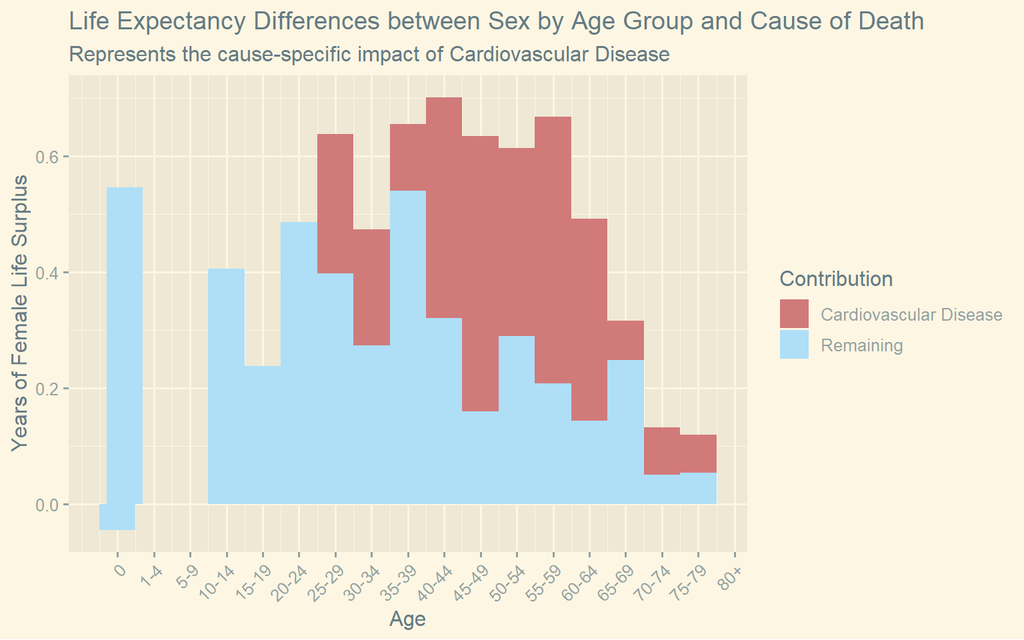

```r
# create long data to plot
decomp$heart_failure = decomp$`n∆ix`
decomp$remaining = decomp$`n∆x` - decomp$`n∆ix`
decomp_toplot = decomp %>%
  select(x, remaining, heart_failure) %>%
  pivot_longer(cols = c(remaining, heart_failure),
               names_to = "type",
               values_to = "value") %>%
  mutate(type = ifelse(type == "heart_failure",
                       "Cardiovascular Disease",
                       "Remaining"))

# plot
p = ggplot(decomp_toplot, aes(x = x, y = value, fill = type)) +
  geom_col(stat = "identity", position = "stack", width = 5) +
  scale_x_continuous(breaks = seq(0, 85, by = 5),
                     labels = c("0",
                                      "1-4",
                                      "5-9",
                                      "10-14",
                                      "15-19",
                                      "20-24",
                                      "25-29",
                                      "30-34",
                                      "35-39",
                                      "40-44",
                                      "45-49",
                                      "50-54",
                                      "55-59",
                                      "60-64",
                                      "65-69",
                                      "70-74",
                                      "75-79",
                                      "80+")) +
  scale_y_continuous("Years of Female Life Surplus") +
  scale_fill_manual(values = c("Remaining" = "#AEDFF7",
                               "Cardiovascular Disease" = "#D17A7A")) +
  labs(x = "Age",
       y = "Years",
       title = "Life Expectancy Differences between Sex by Age Group and Cause of Death",
       subtitle = "Represents the cause-specific impact of Cardiovascular Disease",
       fill = "Contribution") +
  theme_solarized_2() +
  theme(axis.text.x = element_text(angle = 45, hjust = 1))

p
```

```r
ggsave("stacked_bar_cause_specific.png", p)
```

# Sulivan Method for Impairment

Use the Sulivan Method to calculate life left without getting some form of vision loss

## Calculate $H_x$

```r
life_table_female$Hx = 1 - df_female$blindess / df_female$pop
life_table_male$Hx = 1 - df_male$blindess / df_male$pop
```

## Female Table 2015 (Partial or Total Loss of Vision)

```r
life_table_female %>%
  gt() %>%
  tab_style(style = cell_fill(color = "#1F78B4"),
            locations = cells_column_labels(columns = 1:14))
```

| x | n | nNx | nDx | nmx | nax | nqx | npx | lx | ndx | nLx | Tx | ex | Hx |
| --- | --- | --- | --- | --- | --- | --- | --- | --- | --- | --- | --- | --- | --- |
| 0 | 1 | 109 | 1 | 0.009174312 | 0.06962385 | 0.009096667 | 0.9909033 | 100000.00 | 909.6667 | 99153.67 | 7149946.8 | 71.499468 | 1.0000000 |
| 1 | 4 | 467 | 0 | 0.000000000 | 1.65100000 | 0.000000000 | 1.0000000 | 99090.33 | 0.0000 | 396361.33 | 7050793.1 | 71.155207 | 0.9935760 |
| 5 | 5 | 597 | 0 | 0.000000000 | 2.00000000 | 0.000000000 | 1.0000000 | 99090.33 | 0.0000 | 495451.67 | 6654431.8 | 67.155207 | 0.9899497 |
| 10 | 5 | 600 | 0 | 0.000000000 | 2.73000000 | 0.000000000 | 1.0000000 | 99090.33 | 0.0000 | 495451.67 | 6158980.1 | 62.155207 | 0.9900000 |
| 15 | 5 | 580 | 0 | 0.000000000 | 2.58000000 | 0.000000000 | 1.0000000 | 99090.33 | 0.0000 | 495451.67 | 5663528.5 | 57.155207 | 0.9896552 |
| 20 | 5 | 521 | 1 | 0.001919386 | 2.69000000 | 0.009554566 | 0.9904454 | 99090.33 | 946.7651 | 493264.64 | 5168076.8 | 52.155207 | 0.9904031 |
| 25 | 5 | 537 | 1 | 0.001862197 | 2.56000000 | 0.009268871 | 0.9907311 | 98143.57 | 909.6801 | 488498.22 | 4674812.2 | 47.632384 | 0.9888268 |
| 30 | 5 | 586 | 1 | 0.001706485 | 2.61000000 | 0.008497765 | 0.9915022 | 97233.89 | 826.2707 | 484194.65 | 4186314.0 | 43.054063 | 0.9846416 |
| 35 | 5 | 628 | 2 | 0.003184713 | 2.59000000 | 0.015802282 | 0.9841977 | 96407.62 | 1523.4603 | 478366.55 | 3702119.3 | 38.400693 | 0.9745223 |
| 40 | 5 | 701 | 3 | 0.004279601 | 2.66000000 | 0.021185842 | 0.9788142 | 94884.16 | 2010.2008 | 469716.92 | 3223752.8 | 33.975669 | 0.9529244 |
| 45 | 5 | 683 | 4 | 0.005856515 | 2.63000000 | 0.028881701 | 0.9711183 | 92873.96 | 2682.3578 | 458012.59 | 2754035.8 | 29.653478 | 0.9165447 |
| 50 | 5 | 643 | 6 | 0.009331260 | 2.63000000 | 0.045646815 | 0.9543532 | 90191.60 | 4116.9592 | 441200.80 | 2296023.2 | 25.457174 | 0.8631415 |
| 55 | 5 | 544 | 7 | 0.012867647 | 2.67000000 | 0.062465421 | 0.9375346 | 86074.64 | 5376.6886 | 417845.51 | 1854822.4 | 21.549001 | 0.7849265 |
| 60 | 5 | 406 | 8 | 0.019704433 | 2.69000000 | 0.094232944 | 0.9057671 | 80697.95 | 7604.4054 | 385923.58 | 1436976.9 | 17.806858 | 0.6896552 |
| 65 | 5 | 299 | 9 | 0.030100334 | 2.61000000 | 0.140401236 | 0.8595988 | 73093.55 | 10262.4240 | 340940.53 | 1051053.4 | 14.379565 | 0.5652174 |
| 70 | 5 | 174 | 8 | 0.045977011 | 2.68000000 | 0.207727462 | 0.7922725 | 62831.12 | 13051.7493 | 283875.55 | 710112.8 | 11.301928 | 0.4367816 |
| 75 | 5 | 93 | 7 | 0.075268817 | 2.49000000 | 0.316541557 | 0.6834584 | 49779.37 | 15757.2399 | 209346.19 | 426237.3 | 8.562528 | 0.3118280 |
| 80 | NA | 102 | 16 | 0.156862745 | 6.37499645 | 1.000000000 | 0.0000000 | 34022.13 | 34022.1319 | 216891.09 | 216891.1 | 6.375000 | 0.1862745 |

## Male Table 2015 (Partial or Total Loss of Vision)

```r
life_table_male %>%
  gt() %>%
  tab_style(style = cell_fill(color = "#1F78B4"),
            locations = cells_column_labels(columns = 1:14))
```

| x | n | nNx | nDx | nmx | nax | nqx | npx | lx | ndx | nLx | Tx | ex | Hx |
| --- | --- | --- | --- | --- | --- | --- | --- | --- | --- | --- | --- | --- | --- |
| 0 | 1 | 117 | 1 | 0.008547009 | 0.06794017 | 0.008479458 | 0.9915205 | 100000.00 | 847.9458 | 99209.66 | 6441802.7 | 64.41803 | 1.0000000 |
| 1 | 4 | 502 | 1 | 0.001992032 | 1.64539044 | 0.007930928 | 0.9920691 | 99152.05 | 786.3678 | 394756.63 | 6342593.1 | 63.96835 | 0.9940239 |
| 5 | 5 | 646 | 0 | 0.000000000 | 2.09000000 | 0.000000000 | 1.0000000 | 98365.69 | 0.0000 | 491828.43 | 5947836.4 | 60.46658 | 0.9907121 |
| 10 | 5 | 637 | 0 | 0.000000000 | 2.79000000 | 0.000000000 | 1.0000000 | 98365.69 | 0.0000 | 491828.43 | 5456008.0 | 55.46658 | 0.9905808 |
| 15 | 5 | 657 | 1 | 0.001522070 | 2.67000000 | 0.007583456 | 0.9924165 | 98365.69 | 745.9518 | 490090.36 | 4964179.6 | 50.46658 | 0.9908676 |
| 20 | 5 | 687 | 2 | 0.002911208 | 2.70000000 | 0.014459225 | 0.9855408 | 97619.73 | 1411.5057 | 484852.21 | 4474089.2 | 45.83181 | 0.9912664 |
| 25 | 5 | 729 | 3 | 0.004115226 | 2.49000000 | 0.020365769 | 0.9796342 | 96208.23 | 1959.3546 | 476123.16 | 3989237.0 | 41.46461 | 0.9903978 |
| 30 | 5 | 787 | 4 | 0.005082592 | 2.63000000 | 0.025110486 | 0.9748895 | 94248.87 | 2366.6351 | 465635.45 | 3513113.8 | 37.27486 | 0.9860229 |
| 35 | 5 | 823 | 5 | 0.006075334 | 2.54000000 | 0.029929367 | 0.9700706 | 91882.24 | 2749.9772 | 452646.25 | 3047478.4 | 33.16722 | 0.9769137 |
| 40 | 5 | 887 | 8 | 0.009019166 | 2.65000000 | 0.044159859 | 0.9558401 | 89132.26 | 3936.0681 | 436411.55 | 2594832.1 | 29.11215 | 0.9582864 |
| 45 | 5 | 831 | 10 | 0.012033694 | 2.64000000 | 0.058506904 | 0.9414931 | 85196.19 | 4984.5655 | 414217.39 | 2158420.6 | 25.33471 | 0.9265945 |
| 50 | 5 | 733 | 12 | 0.016371078 | 2.65000000 | 0.078822911 | 0.9211771 | 80211.63 | 6322.5141 | 386200.23 | 1744203.2 | 21.74502 | 0.8772169 |
| 55 | 5 | 596 | 13 | 0.021812081 | 2.69000000 | 0.103828890 | 0.8961711 | 73889.11 | 7671.8247 | 351723.66 | 1358003.0 | 18.37893 | 0.8104027 |
| 60 | 5 | 421 | 14 | 0.033254157 | 2.63000000 | 0.154123916 | 0.8458761 | 66217.29 | 10205.6680 | 306899.01 | 1006279.3 | 15.19662 | 0.7292162 |
| 65 | 5 | 287 | 13 | 0.045296167 | 2.58000000 | 0.204107266 | 0.7958927 | 56011.62 | 11432.3790 | 252391.75 | 699380.3 | 12.48634 | 0.6271777 |
| 70 | 5 | 145 | 9 | 0.062068966 | 2.52000000 | 0.268945733 | 0.7310543 | 44579.24 | 11989.3971 | 193162.51 | 446988.5 | 10.02683 | 0.5172414 |
| 75 | 5 | 68 | 6 | 0.088235294 | 2.42000000 | 0.359367513 | 0.6406325 | 32589.85 | 11711.7318 | 132732.96 | 253826.0 | 7.78850 | 0.3970588 |
| 80 | NA | 87 | 15 | 0.172413793 | 5.79999898 | 1.000000000 | 0.0000000 | 20878.11 | 20878.1138 | 121093.06 | 121093.1 | 5.80000 | 0.2873563 |

# Calculating $_nL^H_x$ and $T^H_x$

```r
# nLHx
life_table_female$nLHx = life_table_female$nLx * life_table_female$Hx
life_table_male$nLHx = life_table_male$nLx * life_table_male$Hx

# THx
life_table_female$THx = rev(cumsum(rev(life_table_female$nLHx)))
life_table_male$THx = rev(cumsum(rev(life_table_male$nLHx)))
```

## Female Table 2015 (Partial or Total Loss of Vision)

```r
life_table_female %>%
  select(x, nNx, nDx, nLx, Tx, ex, Hx, nLHx, THx) %>% # cut so it fits
  gt() %>%
  tab_style(style = cell_fill(color = "#1F78B4"),
            locations = cells_column_labels(columns = 1:9))
```

| x | nNx | nDx | nLx | Tx | ex | Hx | nLHx | THx |
| --- | --- | --- | --- | --- | --- | --- | --- | --- |
| 0 | 109 | 1 | 99153.67 | 7149946.8 | 71.499468 | 1.0000000 | 99153.67 | 6143495.56 |
| 1 | 467 | 0 | 396361.33 | 7050793.1 | 71.155207 | 0.9935760 | 393815.11 | 6044341.89 |
| 5 | 597 | 0 | 495451.67 | 6654431.8 | 67.155207 | 0.9899497 | 490472.25 | 5650526.78 |
| 10 | 600 | 0 | 495451.67 | 6158980.1 | 62.155207 | 0.9900000 | 490497.15 | 5160054.53 |
| 15 | 580 | 0 | 495451.67 | 5663528.5 | 57.155207 | 0.9896552 | 490326.30 | 4669557.38 |
| 20 | 521 | 1 | 493264.64 | 5168076.8 | 52.155207 | 0.9904031 | 488530.81 | 4179231.07 |
| 25 | 537 | 1 | 488498.22 | 4674812.2 | 47.632384 | 0.9888268 | 483040.14 | 3690700.26 |
| 30 | 586 | 1 | 484194.65 | 4186314.0 | 43.054063 | 0.9846416 | 476758.22 | 3207660.12 |
| 35 | 628 | 2 | 478366.55 | 3702119.3 | 38.400693 | 0.9745223 | 466178.86 | 2730901.90 |
| 40 | 701 | 3 | 469716.92 | 3223752.8 | 33.975669 | 0.9529244 | 447604.71 | 2264723.04 |
| 45 | 683 | 4 | 458012.59 | 2754035.8 | 29.653478 | 0.9165447 | 419788.99 | 1817118.33 |
| 50 | 643 | 6 | 441200.80 | 2296023.2 | 25.457174 | 0.8631415 | 380818.73 | 1397329.34 |
| 55 | 544 | 7 | 417845.51 | 1854822.4 | 21.549001 | 0.7849265 | 327978.00 | 1016510.61 |
| 60 | 406 | 8 | 385923.58 | 1436976.9 | 17.806858 | 0.6896552 | 266154.19 | 688532.60 |
| 65 | 299 | 9 | 340940.53 | 1051053.4 | 14.379565 | 0.5652174 | 192705.52 | 422378.41 |
| 70 | 174 | 8 | 283875.55 | 710112.8 | 11.301928 | 0.4367816 | 123991.62 | 229672.89 |
| 75 | 93 | 7 | 209346.19 | 426237.3 | 8.562528 | 0.3118280 | 65279.99 | 105681.28 |
| 80 | 102 | 16 | 216891.09 | 216891.1 | 6.375000 | 0.1862745 | 40401.28 | 40401.28 |

## Male Table 2015 (Partial or Total Loss of Vision)

```r
life_table_male %>%
  select(x, nNx, nDx, nLx, Tx, ex, Hx, nLHx, THx) %>% # cut so it fits
  gt() %>%
  tab_style(style = cell_fill(color = "#1F78B4"),
            locations = cells_column_labels(columns = 1:9))
```

| x | nNx | nDx | nLx | Tx | ex | Hx | nLHx | THx |
| --- | --- | --- | --- | --- | --- | --- | --- | --- |
| 0 | 117 | 1 | 99209.66 | 6441802.7 | 64.41803 | 1.0000000 | 99209.66 | 5800510.04 |
| 1 | 502 | 1 | 394756.63 | 6342593.1 | 63.96835 | 0.9940239 | 392397.52 | 5701300.38 |
| 5 | 646 | 0 | 491828.43 | 5947836.4 | 60.46658 | 0.9907121 | 487260.37 | 5308902.85 |
| 10 | 637 | 0 | 491828.43 | 5456008.0 | 55.46658 | 0.9905808 | 487195.82 | 4821642.49 |
| 15 | 657 | 1 | 490090.36 | 4964179.6 | 50.46658 | 0.9908676 | 485614.65 | 4334446.66 |
| 20 | 687 | 2 | 484852.21 | 4474089.2 | 45.83181 | 0.9912664 | 480617.69 | 3848832.01 |
| 25 | 729 | 3 | 476123.16 | 3989237.0 | 41.46461 | 0.9903978 | 471551.34 | 3368214.32 |
| 30 | 787 | 4 | 465635.45 | 3513113.8 | 37.27486 | 0.9860229 | 459127.20 | 2896662.98 |
| 35 | 823 | 5 | 452646.25 | 3047478.4 | 33.16722 | 0.9769137 | 442196.34 | 2437535.78 |
| 40 | 887 | 8 | 436411.55 | 2594832.1 | 29.11215 | 0.9582864 | 418207.23 | 1995339.44 |
| 45 | 831 | 10 | 414217.39 | 2158420.6 | 25.33471 | 0.9265945 | 383811.55 | 1577132.21 |
| 50 | 733 | 12 | 386200.23 | 1744203.2 | 21.74502 | 0.8772169 | 338781.38 | 1193320.66 |
| 55 | 596 | 13 | 351723.66 | 1358003.0 | 18.37893 | 0.8104027 | 285037.80 | 854539.28 |
| 60 | 421 | 14 | 306899.01 | 1006279.3 | 15.19662 | 0.7292162 | 223795.72 | 569501.49 |
| 65 | 287 | 13 | 252391.75 | 699380.3 | 12.48634 | 0.6271777 | 158294.48 | 345705.77 |
| 70 | 145 | 9 | 193162.51 | 446988.5 | 10.02683 | 0.5172414 | 99911.64 | 187411.29 |
| 75 | 68 | 6 | 132732.96 | 253826.0 | 7.78850 | 0.3970588 | 52702.79 | 87499.65 |
| 80 | 87 | 15 | 121093.06 | 121093.1 | 5.80000 | 0.2873563 | 34796.86 | 34796.86 |

# Healthy vs Unhealthy Life Expectancy

Calculate E Dagger for Healthy and Unhealthy years left

```r
# eHx
life_table_female$eHx = life_table_female$THx /
  life_table_female$lx
life_table_male$eHx = life_table_male$THx /
  life_table_male$lx

# eUNx
life_table_female$eUNx = life_table_female$ex -
  life_table_female$eHx
life_table_male$eUNx = life_table_male$ex -
  life_table_male$eHx
```

## Female Table 2015 (Partial or Total Loss of Vision)

```r
life_table_female %>%
  select(x, nLx, Tx, ex, Hx,
         nLHx, THx, eHx, eUNx) %>% # cut so it fits
  gt() %>%
  tab_style(style = cell_fill(color = "#1F78B4"),
            locations = cells_column_labels(columns = 1:9))
```

| x | nLx | Tx | ex | Hx | nLHx | THx | eHx | eUNx |
| --- | --- | --- | --- | --- | --- | --- | --- | --- |
| 0 | 99153.67 | 7149946.8 | 71.499468 | 1.0000000 | 99153.67 | 6143495.56 | 61.434956 | 10.064513 |
| 1 | 396361.33 | 7050793.1 | 71.155207 | 0.9935760 | 393815.11 | 6044341.89 | 60.998300 | 10.156907 |
| 5 | 495451.67 | 6654431.8 | 67.155207 | 0.9899497 | 490472.25 | 5650526.78 | 57.023996 | 10.131211 |
| 10 | 495451.67 | 6158980.1 | 62.155207 | 0.9900000 | 490497.15 | 5160054.53 | 52.074247 | 10.080959 |
| 15 | 495451.67 | 5663528.5 | 57.155207 | 0.9896552 | 490326.30 | 4669557.38 | 47.124247 | 10.030959 |
| 20 | 493264.64 | 5168076.8 | 52.155207 | 0.9904031 | 488530.81 | 4179231.07 | 42.175971 | 9.979235 |
| 25 | 488498.22 | 4674812.2 | 47.632384 | 0.9888268 | 483040.14 | 3690700.26 | 37.605116 | 10.027269 |
| 30 | 484194.65 | 4186314.0 | 43.054063 | 0.9846416 | 476758.22 | 3207660.12 | 32.989117 | 10.064946 |
| 35 | 478366.55 | 3702119.3 | 38.400693 | 0.9745223 | 466178.86 | 2730901.90 | 28.326620 | 10.074073 |
| 40 | 469716.92 | 3223752.8 | 33.975669 | 0.9529244 | 447604.71 | 2264723.04 | 23.868295 | 10.107375 |
| 45 | 458012.59 | 2754035.8 | 29.653478 | 0.9165447 | 419788.99 | 1817118.33 | 19.565424 | 10.088054 |
| 50 | 441200.80 | 2296023.2 | 25.457174 | 0.8631415 | 380818.73 | 1397329.34 | 15.492899 | 9.964275 |
| 55 | 417845.51 | 1854822.4 | 21.549001 | 0.7849265 | 327978.00 | 1016510.61 | 11.809641 | 9.739359 |
| 60 | 385923.58 | 1436976.9 | 17.806858 | 0.6896552 | 266154.19 | 688532.60 | 8.532219 | 9.274639 |
| 65 | 340940.53 | 1051053.4 | 14.379565 | 0.5652174 | 192705.52 | 422378.41 | 5.778601 | 8.600964 |
| 70 | 283875.55 | 710112.8 | 11.301928 | 0.4367816 | 123991.62 | 229672.89 | 3.655400 | 7.646528 |
| 75 | 209346.19 | 426237.3 | 8.562528 | 0.3118280 | 65279.99 | 105681.28 | 2.122993 | 6.439535 |
| 80 | 216891.09 | 216891.1 | 6.375000 | 0.1862745 | 40401.28 | 40401.28 | 1.187500 | 5.187500 |

## Male Table 2015 (Partial or Total Loss of Vision)

```r
life_table_male %>%
  select(x, nLx, Tx, ex, Hx,
         nLHx, THx, eHx, eUNx) %>% # cut so it fits
  gt() %>%
  tab_style(style = cell_fill(color = "#1F78B4"),
            locations = cells_column_labels(columns = 1:9))
```

| x | nLx | Tx | ex | Hx | nLHx | THx | eHx | eUNx |
| --- | --- | --- | --- | --- | --- | --- | --- | --- |
| 0 | 99209.66 | 6441802.7 | 64.41803 | 1.0000000 | 99209.66 | 5800510.04 | 58.005100 | 6.412927 |
| 1 | 394756.63 | 6342593.1 | 63.96835 | 0.9940239 | 392397.52 | 5701300.38 | 57.500578 | 6.467770 |
| 5 | 491828.43 | 5947836.4 | 60.46658 | 0.9907121 | 487260.37 | 5308902.85 | 53.971085 | 6.495492 |
| 10 | 491828.43 | 5456008.0 | 55.46658 | 0.9905808 | 487195.82 | 4821642.49 | 49.017525 | 6.449053 |
| 15 | 490090.36 | 4964179.6 | 50.46658 | 0.9908676 | 485614.65 | 4334446.66 | 44.064621 | 6.401957 |
| 20 | 484852.21 | 4474089.2 | 45.83181 | 0.9912664 | 480617.69 | 3848832.01 | 39.426782 | 6.405029 |
| 25 | 476123.16 | 3989237.0 | 41.46461 | 0.9903978 | 471551.34 | 3368214.32 | 35.009628 | 6.454985 |
| 30 | 465635.45 | 3513113.8 | 37.27486 | 0.9860229 | 459127.20 | 2896662.98 | 30.734192 | 6.540671 |
| 35 | 452646.25 | 3047478.4 | 33.16722 | 0.9769137 | 442196.34 | 2437535.78 | 26.528911 | 6.638308 |
| 40 | 436411.55 | 2594832.1 | 29.11215 | 0.9582864 | 418207.23 | 1995339.44 | 22.386276 | 6.725878 |
| 45 | 414217.39 | 2158420.6 | 25.33471 | 0.9265945 | 383811.55 | 1577132.21 | 18.511768 | 6.822938 |
| 50 | 386200.23 | 1744203.2 | 21.74502 | 0.8772169 | 338781.38 | 1193320.66 | 14.877153 | 6.867864 |
| 55 | 351723.66 | 1358003.0 | 18.37893 | 0.8104027 | 285037.80 | 854539.28 | 11.565158 | 6.813773 |
| 60 | 306899.01 | 1006279.3 | 15.19662 | 0.7292162 | 223795.72 | 569501.49 | 8.600495 | 6.596129 |
| 65 | 252391.75 | 699380.3 | 12.48634 | 0.6271777 | 158294.48 | 345705.77 | 6.172036 | 6.314306 |
| 70 | 193162.51 | 446988.5 | 10.02683 | 0.5172414 | 99911.64 | 187411.29 | 4.204003 | 5.822827 |
| 75 | 132732.96 | 253826.0 | 7.78850 | 0.3970588 | 52702.79 | 87499.65 | 2.684875 | 5.103626 |
| 80 | 121093.06 | 121093.1 | 5.80000 | 0.2873563 | 34796.86 | 34796.86 | 1.666667 | 4.133333 |